# 中斷時間序列（Interrupted Time Series, ITS）Skill

用分段迴歸判斷「事件發生後，有沒有改變？」

# 01｜要解決什麼問題

政策上路、法規生效、新療程開始、建設完工之後，我們常想知道：**這件事發生後，數值有沒有改變？** 例如「安全帶法上路後，駕駛死亡人數有沒有下降？」「健保給付新制實施後，處方量的趨勢有沒有改變？」

最直覺的做法是「比較介入前後的平均」，但在時間序列上這樣做常常會錯：

| 陷阱 | 說明 |
| --- | --- |
| **原本就有的趨勢** | 序列本來就在下降，介入後平均自然比較低，但這不是介入的效果 |
| **季節性** | 前後兩段涵蓋的月份不同，平均數就會不一樣 |
| **均值回歸** | 政策常在數值異常高時推出，之後的回落本來就會發生 |

**中斷時間序列（Interrupted Time Series, ITS）**的想法是：用介入**前**的趨勢推估「如果沒有介入會怎樣」，也就是**反事實（counterfactual）**，再拿介入後的實際值跟它比較。ITS 是準實驗設計；在無法隨機分派時（例如全國性政策），它是評估介入效果最有力的設計之一。

所以，**拿到下面這樣的資料，就可以用這個 skill**：

- **一條時間序列**：依時間排序、間隔相等（年、季、月、週、日）
- **一個已知的介入時間點**：例如政策上路、法規生效的日期
- **想回答的問題**：介入之後，數值的**水準**有沒有跳動？**趨勢**有沒有改變？

# 02｜核心模型：分段迴歸

$$Y_t = \beta_0 + \beta_1 T_t + \beta_2 X_t + \beta_3 (T_t - T_0) X_t + \gamma\,\text{季節項} + \varepsilon_t$$

| 公式中的項 | 變數的意義 | 係數 | 係數的解釋 |
| --- | --- | --- | --- |
| 截距 | — | $\beta_0$ | 序列起點（$T = 0$）的水準 |
| $T_t$ | 時間：1, 2, 3, … | $\beta_1$ | 介入**前**的斜率：每期變多少 |
| $X_t$ | 介入前 = 0，介入後 = 1 | $\beta_2$ | **水準變化**：介入當下跳了多少 |
| $(T_t - T_0)X_t$ | 介入後經過的期數（介入前 = 0） | $\beta_3$ | **斜率變化**：介入後斜率 = $\beta_1 + \beta_3$ |
| 季節項 | 月資料用月份虛擬變數（季資料用季別）；年資料不加 | $\gamma$ | 各月份（季）的差異，避免前後兩段涵蓋的月份不同而扭曲效果 |

- $T_0$ 是**介入開始的時間點**，是固定的常數，不是變數。
- 介入後第 $k$ 期的效果 = $\beta_2 + \beta_3 k$（當下的跳動，加上 $k$ 期累積的斜率改變）。

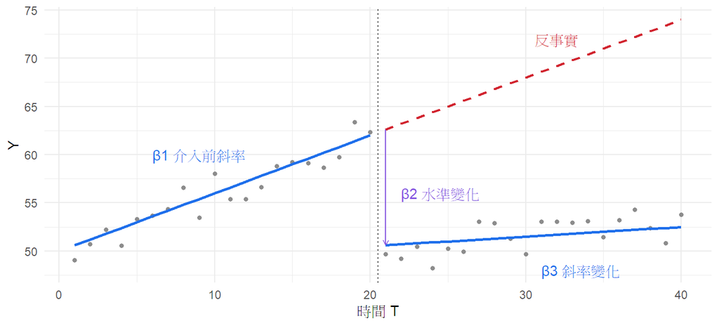

圖 1: 分段迴歸的概念：灰點為觀測值，藍線為配適，紅虛線為反事實；β1 是介入前的斜率，β2 是介入點的垂直跳動，β3 是斜率的改變。

**警告參數化陷阱**

有些文獻把交互作用寫成 $\beta_3 T_t X_t$（沒有減 $T_0$），這時 $\beta_2$ 變成「外推到 $T = 0$ 的水準差」，**不是**介入當下的跳動。本 skill 一律用 $(T_t - T_0)X_t$，讓 $\beta_2$ 可以直接解釋。

# 03｜基本假設

| 假設 | 內容 | 怎麼處理 |
| --- | --- | --- |
| **趨勢延續** | 沒有介入的話，介入前趨勢會持續下去 | 無法直接檢定；看介入前趨勢是否接近線性，做「前段視窗」敏感度分析（只用較近的介入前資料重新估計） |
| **沒有同時事件** | 介入點附近沒有其他會影響結果的事件 | 一定要問使用者；可加共變數 |
| **介入時間明確** | $T_0$ 清楚，或已知過渡期 | 追問；過渡期當敏感度分析 |
| **測量一致** | 介入前後定義、測量方式不變 | 追問 |
| **資料點足夠** | 經驗法則：前後各至少 12 點（Wagner et al., 2002） | 少於 12 點警告，少於 3 點停止 |
| **誤差獨立** | 時間序列**通常不成立** | 一定做殘差診斷；有自相關改用 GLS（見 05 節示範） |

# 04｜完整分析流程

```
flowchart TD
  A(["使用者附上時間序列資料"]) --> Q1{{"第 1 階段 選擇題 ①：結果變數、時間欄、介入時間、頻率"}}
  Q1 --> Q2{{"選擇題 ②：變數型態、生效方式、其他事件、共變數"}}
  Q2 --> C["第 2 階段：資料檢查 its_prepare()"]
  C -->|"缺值、重複、間隔不等、點數 < 3"| X1["說明原因並停止"]
  C -->|"通過"| D["探索：時序圖、季節圖、趨勢彎曲檢定"]
  D --> Q3{{"選擇題 ③：依建議設定配適模型？"}}
  Q3 -->|"先停在探索"| X2["保留探索結果，結束"]
  Q3 -->|"配適"| F["第 3 階段：OLS 分段迴歸 ＋ 殘差診斷"]
  F --> G{"有自相關？"}
  G -->|"否（BG、Ljung–Box p ≥ .05）"| H["主要模型 = OLS"]
  G -->|"是"| I["AIC 比較 GLS AR(0)–AR(4)"]
  I --> Q4{{"選擇題 ④：主要模型用哪一個？"}}
  Q4 --> K["GLS AR(p) ＋ 標準化殘差檢查"]
  H --> L["第 4 階段：β2、β3、相對變化、反事實圖、繁中解釋"]
  K --> L
  L --> S{"有需要檢查的疑慮？"}
  S -->|"有（自相關、趨勢彎曲、計數、共變數、過渡期）"| N["第 5 階段：自動做所有符合條件的敏感度分析"]
  S -->|"都沒有"| O(["產生 HTML 報告"])
  N --> O
  classDef ask fill:#fff4e5,stroke:#d97706,color:#7c2d12
  classDef stop fill:#fde8e8,stroke:#d1242f,color:#7f1d1d
  classDef calc fill:#e8f1fe,stroke:#1f6feb,color:#0b3d91
  classDef io fill:#e9f7ef,stroke:#1a7f37,color:#0f5323
  class Q1,Q2,Q3,Q4 ask
  class X1,X2 stop
  class C,D,F,I,K,H,L,N,G,S calc
  class A,O io
```

圖例：🟧 橘色六角形＝停下來問使用者的選擇題（共 4 次，敏感度分析不問、自動做）｜🟦 藍色＝R 函數計算｜🟥 紅色＝停止點｜🟩 綠色＝開始與結束。

**skill 的核心規則**（寫在 `SKILL.md`，每次分析都照同一套走）

| # | 規則 | 為什麼 |
| --- | --- | --- |
| 1 | 要使用者決定的事**一律用選擇題**，選項從資料產生，建議的放第一個 | 使用者不一定會回答開放式問題；介入時間**不由 AI 自己猜** |
| 2 | 資料有缺值、時間重複、間隔不等、任一段少於 3 點 → **停止** | 不自動插補或刪資料，避免分析建立在錯的資料上 |
| 3 | 頻率 > 1 時**預設加季節項** | 不處理季節，效果會被扭曲（Seatbelts 會高估將近一倍） |
| 4 | **一定要診斷殘差自相關**；有自相關就用 AIC 選 GLS AR(p)，請使用者確認 | 自相關會讓 OLS 的標準誤偏小、p 值太小 |
| 5 | 敏感度分析**依條件自動做**；OLS 和只修正標準誤的方法（Newey–West）**只當對照** | 檢查結論換個設定還站不站得住 |
| 6 | 所有數字都來自 `scripts/its.R` 的函數，報告可完整重現 | 不心算、不臨時補算 |

# 05｜實作示範：安全帶法

## 分析請求

> 「這是英國 1969–1984 年每月的駕駛死亡人數，1983 年 1 月 31 日開始強制前座繫安全帶。法律有沒有效？」

skill 依序確認：結果變數 `DriversKilled`、介入起點 1983-02（第一個完整月）、月資料、計數但平均約 120（線性模型可用）、立即生效、同期有石油危機與交通量、油價變動。

## 資料探索

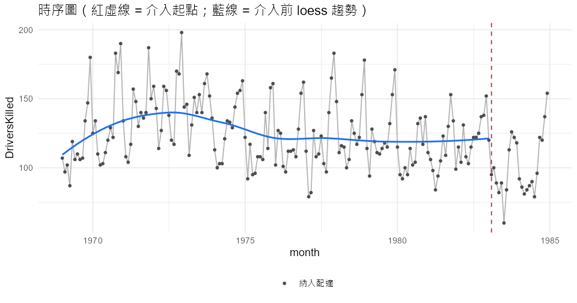

時序圖：介入前趨勢先升後降（1973–74 石油危機），二次項檢定 p = 0.089

## 模型怎麼選

- **季節性**：介入前資料的季節性 F 檢定 p < 0.0001，冬季明顯較多 → 加月份虛擬變數（規則 3）。
- **自相關**：OLS ＋ 月份的殘差 lag 1 自相關 = 0.39，Breusch–Godfrey 檢定 p < 0.0001 → 不能只看 OLS（規則 4）。
- **AR 階數**：比較 GLS AR(0)–AR(4)，AIC 最小的是 AR(1) → 主要模型 = GLS AR(1) ＋ 月份。改用 GLS 後，β2 的標準誤從 7.3 變成 10.2。

## 主要結果

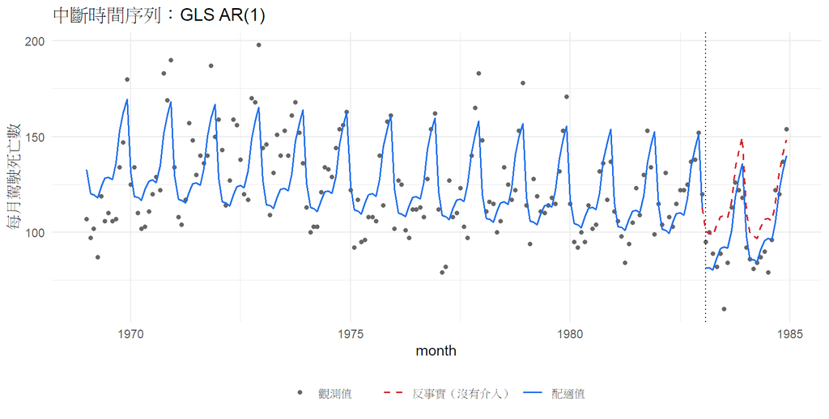

圖 2: GLS AR(1) ＋ 月份：藍線為配適值，紅虛線為反事實（沒有安全帶法時的預期）

表 1

| 估計量 | 估計值 | SE | 95% 下界 | 95% 上界 |
| --- | --- | --- | --- | --- |
| 介入前斜率（每月） | -0.119 | 0.041 | -0.199 | -0.039 |
| **水準變化 β2** | -18.755 | 10.195 | -38.876 | 1.365 |
| 斜率變化 β3（每月） | 0.484 | 0.748 | -0.992 | 1.960 |
| 介入後斜率（每月） | 0.365 | 0.745 | -1.106 | 1.836 |
| **介入後期間的平均相對變化** | -0.117 | 0.056 | -0.228 | -0.007 |

**介入前趨勢**：每月平均減少 0.12 人（95% CI -0.20 到 -0.04）。

**水準變化（β2）**：介入當下，每月駕駛死亡數比依介入前趨勢預期的值減少 18.76 人（95% CI -38.88 到 1.36，p = 0.0675）。信賴區間包含 0，沒有足夠證據顯示介入當下水準改變（不等於證明沒有改變）。

**斜率變化（β3）**：介入後每月的趨勢比介入前多 0.48 人（95% CI -0.99 到 1.96，p = 0.519）。沒有足夠證據顯示趨勢改變。

**介入後斜率**：每月 0.36 人（95% CI -1.11 到 1.84）。

**整體相對變化**：介入後期間，每月駕駛死亡數平均比反事實低 11.7%；相對變化 = -11.7%（95% CI -22.8% 到 -0.7%，p = 0.0374）。這是把整個介入後期間的效果加總後的比例，跟 β2、β3 的單點檢定不同，結論可能不一樣。

ITS 是準實驗設計：以上解釋成立的前提是「沒有介入的話，介入前趨勢會延續」，而且介入點附近沒有其他同時發生的事件。

## 敏感度分析

主要模型是在一組假設下估出來的。敏感度分析每次**只改一個設定**重新估計，看 β2、β3 會不會跟著變：

| 模型 | 怎麼做 | 檢查什麼疑慮 | 結果怎麼看 |
| --- | --- | --- | --- |
| **主要模型** GLS AR(1) ＋ 月份 | 基準 | — | 其他列都跟它比 |
| **OLS（未處理自相關）** | 同樣的分段迴歸，但假設相鄰月份的誤差互相獨立 | 忽略自相關會怎樣 | 係數接近，但 CI 偏窄、容易誤判顯著，**只當對照** |
| **OLS ＋ Newey–West** | OLS 的係數，改用 Newey–West 修正標準誤 | 另一種處理自相關的做法 | 小樣本下標準誤仍偏小，**只當對照** |
| **＋ 共變數**（kms、PetrolPrice） | 模型加入每月行駛里程和油價 | **同時事件**：死亡下降會不會只是因為大家少開車、油價變貴 | 加入後 β2 仍為負且大小相近 → 下降不完全是交通量、油價造成的 |
| **排除介入後前 2 期** | 1983-02、1983-03 不拿來估計 | **介入時間**：法律可能要一段時間才完全生效，頭幾個月可能異常 | β2 沒有變小 → 效果不是只靠頭兩個月撐起來的 |
| **只用介入前最近 96 期** | 只用 1975-02 之後的介入前資料估趨勢 | **趨勢延續**：1973–74 石油危機讓介入前趨勢彎曲，直線外推的反事實可能不準 | β2 跟主要模型差不多或更明確 → 結論不是被早期那段彎曲帶出來的 |
| **quasi-Poisson** | 把死亡數當計數資料，用率比表示效果，並允許變異比平均大 | **模型形式**：把計數當連續數值處理是否恰當 | 率比 < 1 表示下降；它的標準誤也用 Newey–West，CI 可能偏窄 |

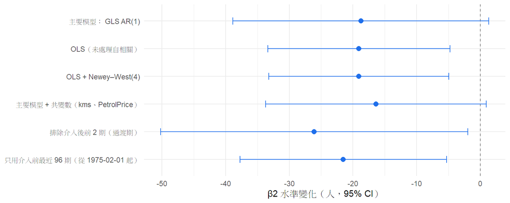

圖 3: 敏感度分析：β2 水準變化（點 = 估計值，橫線 = 95% CI，虛線 = 0）

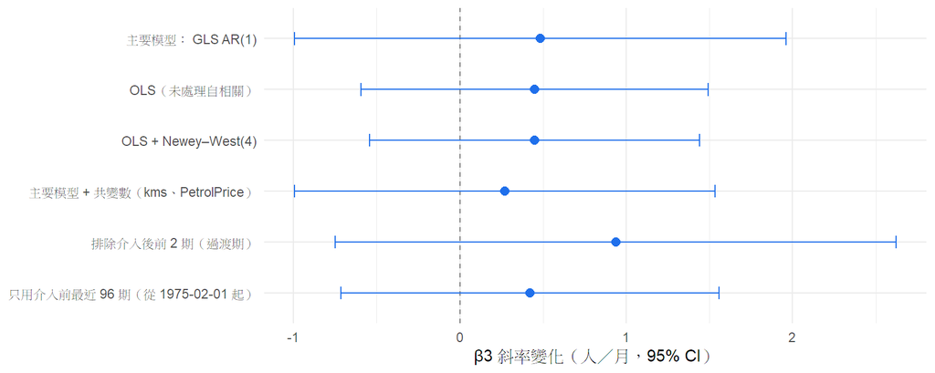

圖 4: 敏感度分析：β3 斜率變化（點 = 估計值，橫線 = 95% CI，虛線 = 0）

表 2

| 模型 | 檢查什麼 | β2 水準變化（95% CI） | β3 斜率變化（95% CI） |
| --- | --- | --- | --- |
| 主要模型： GLS AR(1) | 主要模型 | -18.8（-38.9 ~ 1.4） | 0.48（-0.99 ~ 1.96） |
| OLS（未處理自相關） | 只當對照 | -19.1（-33.4 ~ -4.8） ✱ | 0.45（-0.59 ~ 1.49） |
| OLS + Newey–West(4) | 只當對照 | -19.1（-33.2 ~ -4.9） ✱ | 0.45（-0.54 ~ 1.44） |
| 主要模型 + 共變數（kms、PetrolPrice） | 下降是不是因為少開車、油價變動？ | -16.4（-33.7 ~ 0.9） | 0.27（-0.99 ~ 1.53） |
| 排除介入後前 2 期（過渡期） | 法律是不是要一段時間才生效？ | -26.1（-50.2 ~ -1.9） ✱ | 0.94（-0.75 ~ 2.62） |
| 只用介入前最近 96 期（從 1975-02-01 起） | 避開石油危機，反事實會不會不同？ | -21.5（-37.7 ~ -5.3） ✱ | 0.42（-0.71 ~ 1.56） |
| quasi-Poisson + Newey–West(4) | 把死亡數當計數資料（率比；CI 可能偏窄） | 率比 0.813（0.710 ~ 0.930） ✱ | 率比 1.006（0.996 ~ 1.016） |

✱ = 95% CI 不含 0（率比則為不含 1）。

- **β2 水準變化**：所有模型都是下降。撇開只當對照的 OLS 和 Newey–West，4 個模型中有 2 個顯著 →「介入當下的跳動是否顯著」取決於設定，不穩健。
- **β3 斜率變化**：4 個模型中有 0 個顯著，點估計都接近 0 →在所有設定下都**沒有證據顯示趨勢改變**。介入後只有 23 個月，斜率本來就不容易估準。

**結論**：安全帶法上路後，每月駕駛死亡數**方向一致地下降**（約 16–26 人，或約 19%）；但在把自相關納入考量的主要模型中，水準變化的 95% CI 剛好包含 0。趨勢則在所有設定下都沒有證據顯示改變。比較精確的說法是「資料支持法律降低了駕駛死亡，但單看介入當下的跳動，統計上仍有不確定性」，而不是簡單的「有效／無效」。這正是 skill 要求同時呈現 CI 和敏感度分析的原因。

# 06｜限制與貢獻

**限制**

- ITS 的因果解釋建立在「趨勢延續」和「沒有同時事件」兩個無法直接檢定的假設上；skill 只能追問、做敏感度分析，不能保證假設成立。
- 第一版只支援單一序列、單一介入點；**不支援**控制序列、多個介入點、面板資料。
- GLS 在小樣本下略為寬鬆（模擬涵蓋率約 92–93%，見 skill 內的 `VALIDATION.md`）。
- 計數資料的 quasi-Poisson 只用 Newey–West 處理自相關，小樣本同樣不可靠。

**貢獻**

- 把「季節性一定要處理」「自相關一定要診斷」「不能只靠修正標準誤（Newey–West）就下結論」這些**容易被跳過的判斷**，寫成固定規則和停止點（見 04 節的核心規則）。
- 用模擬**量化**了跳過這些步驟的代價：OLS 誤判率約 30%（見 `VALIDATION.md`）。
- 所有數字由經過驗收的函數產生（21 項驗收全部通過，見 `VALIDATION.md`），報告可以從保存的狀態完整重現。

**未來方向**：比較組 ITS（加控制序列）、ARIMA 介入模型、多介入點、斷點偵測的前處理。

# 參考資料

- Bernal, J. L., Cummins, S., & Gasparrini, A. (2017). Interrupted time series regression for the evaluation of public health interventions: a tutorial. *International Journal of Epidemiology, 46*(1), 348–355.
- Harvey, A. C., & Durbin, J. (1986). The effects of seat belt legislation on British road casualties: A case study in structural time series modelling. *Journal of the Royal Statistical Society, Series A, 149*(3), 187–227.
- Hyndman, R. J., & Athanasopoulos, G. (2021). *Forecasting: Principles and Practice* (3rd ed.). OTexts.
- Wagner, A. K., Soumerai, S. B., Zhang, F., & Ross-Degnan, D. (2002). Segmented regression analysis of interrupted time series studies in medication use research. *Journal of Clinical Pharmacy and Therapeutics, 27*(4), 299–309.
- R 套件：`nlme`、`sandwich`、`lmtest`、`ggplot2`；資料：R 內建 `Seatbelts`。

# 附錄 A｜在 Claude 上使用這個 skill

skill 安裝在 `~/.claude/skills/its-intervention/`。在 Claude Code 中提到「介入分析」「中斷時間序列」「政策實施後有沒有效」並附上資料，就會觸發。

```
its-intervention/
├── SKILL.md                 流程與停止點
├── scripts/its.R            所有計算函數
├── scripts/finalize_report.R 產生報告
├── references/              方法說明、決策樹
├── assets/report.qmd        報告模板；seatbelts.csv
├── tests/validate.R         驗收腳本
└── VALIDATION.md            驗收紀錄
```

**對話示意**

> **使用者**：幫我看安全帶法有沒有效 `seatbelts.csv`

> **Claude**：我已讀取 seatbelts.csv：192 筆、9 個欄位，時間從 1969-01 到 1984-12，看起來是月資料。請先回答 4 題選擇題：

> 【結果變數】要分析哪一欄的變化？ ● `DriversKilled`（建議） ○ `front` ○ `rear` ○ `VanKilled` ○ 其他

> 【介入時間】介入從哪一期開始？ ● 1983-02（建議：法律 1/31 生效後第一個完整月） ○ 1983-01 ○ 其他

> ……（另外 6 題、資料檢查、探索圖、建議設定）……

> **Claude**：OLS 殘差有自相關（Breusch–Godfrey p < 0.0001）。主要模型要用哪一個？ ● GLS AR(1)（建議，AIC 最小） ○ GLS AR(2) ○ 仍用 OLS（不建議：SE 會被低估） ○ 其他

# 附錄 B｜可重現性

- 所有分析由 `scripts/its.R` 的函數產生；報告依保存的分析狀態（`state.rds`）重新執行。
- 報告記錄資料 MD5、R 與套件版本、每個確認點的使用者回答。
- 驗收：`Rscript tests/validate.R`（約 2 分鐘），結果寫入 `tests/results/`。

**R 程式碼**

```r
sessionInfo()$R.version$version.string
```

```
[1] "R version 4.4.3 (2025-02-28 ucrt)"
```

**R 程式碼**

```r
sapply(c("nlme", "sandwich", "lmtest", "ggplot2"), function(p) as.character(packageVersion(p)))
```

```
     nlme  sandwich    lmtest   ggplot2
"3.1.167"   "3.1.1"  "0.9.40"   "4.0.2"
```

# 附錄 C｜數學細節

**GLS AR(p)**：$\varepsilon_t = \phi_1\varepsilon_{t-1} + \dots + \phi_p\varepsilon_{t-p} + u_t$，$u_t \sim N(0, \sigma^2)$。誤差的共變異矩陣 $\Sigma(\phi)$ 由 AR 結構決定，$\hat\beta = (X^\top\Sigma^{-1}X)^{-1}X^\top\Sigma^{-1}y$。AR 階數用 ML 估計比較 AIC，最終模型用 REML。

**介入後第 k 期效果**：$\hat\beta_2 + k\hat\beta_3$，變異數 $c^\top \hat V c$，其中 $c$ 在 $X$、$T_{post}$ 位置分別為 1、$k$。

**整體相對變化（delta method）**：$R = \dfrac{a^\top\beta}{b^\top\beta}$，$a$ 為介入後各期效果的加總向量，$b$ 為介入後各期反事實的加總向量；$\nabla R = \dfrac{a}{b^\top\beta} - \dfrac{(a^\top\beta)\,b}{(b^\top\beta)^2}$，$\text{SE}(R) = \sqrt{\nabla R^\top \hat V \nabla R}$。

**Newey–West**：落後期 $L = \lfloor 4(n/100)^{2/9} \rfloor$，Bartlett 權重，不做 prewhitening。